# Gibbs Sampler log

Jeff Gould

5/11/2021

Since volatility follows a log-normal distribution, we may find better accuracy building a model on $\log(Vol)$ instead of the level version

So we set $V_t = \exp(X_t)$, with $X$ as a mean-reverting Gaussian process (also referred to as an Ornstein-Uhlenbeck and Vasicek process), then we get:

$$d X_t = \kappa(\theta - X_t)dt + \epsilon dW_t$$

where $\kappa$ is the mean-reversion parameter, $\theta \approx$ the long-run mean, $\epsilon$ is a diffusion parameter, and $dW_t$ is standard Brownian Motion

$X$ is a Gaussian process, and by extension $V$ is log-normal, and this gives the followign conditional distribution:

$$X_{t+1} | X_t \sim \mathcal{N} \left(X_t e^{-\kappa} + \theta(1 - e^{-\kappa}), \frac{\epsilon^2 (1 - e^{-2 \kappa})}{2 \kappa} \right)$$

This gives $P(X_{t+1} | X_t) = \frac{1}{\sqrt{2 \pi \frac{\epsilon^2 (1 - e^{-2 \kappa})}{2 \kappa}}} \exp \left[-\frac{1}{2\frac{\epsilon^2 (1 - e^{-2 \kappa})}{2 \kappa}} (X_{t+1} - (X_t e^{-\kappa} + \theta(1 - e^{-\kappa})))^2 \right]$

Likelihood function:

$$P(\epsilon^2, \kappa, \theta | X) \propto (\epsilon^2)^{-1} \prod_{t=1}^{n-1} \frac{1}{\sqrt{2 \pi \frac{\epsilon^2 (1 - e^{-2 \kappa})}{2 \kappa}}} \exp \left[-\frac{1}{2\frac{\epsilon^2 (1 - e^{-2 \kappa})}{2 \kappa}} (X_{t+1} - (X_t e^{-\kappa} + \theta(1 - e^{-\kappa})))^2 \right] \\
\propto (\epsilon^2)^{-1} \left[\frac{\epsilon^2 (1 - e^{-2 \kappa})}{2 \kappa} \right]^{-n/2} \exp \left[-\frac{1}{2\frac{\epsilon^2 (1 - e^{-2 \kappa})}{2 \kappa}} \sum \left\{X_{t+1} - (X_t e^{-\kappa} + \theta(1 - e^{-\kappa}))\right\}^2 \right] \\
\propto (\epsilon^2)^{-1} \left[\frac{\kappa^{n/2}}{(\epsilon^2 (1 - e^{-2 \kappa}))^{n/2}} \right]^{-n/2} \exp \left[-\frac{\kappa}{\epsilon^2 (1 - e^{-2 \kappa})} \sum \left\{X_{t+1} - (X_t e^{-\kappa} + \theta(1 - e^{-\kappa}))\right\}^2 \right]$$

So we get $\epsilon^2$ is an Inverse-Gamma r.v, and no closed form solutions for $\kappa$ and $\theta$

Since $\kappa$ is a rate parameter, it is bounded between $[0,1]$. We first start tuning the Sampler by using a Uniform distribution for the MH step, then switch to a $Beta$ distribution when we have a better idea of the center. Since $\theta$ is the long-run mean of $X$, we sample $\theta^*$ from a normal distribution centered at $\bar{X}$, with $\sigma$ tuned to get an ideal acceptance rate.

```r
btc_candles <- read_csv("btcOpenCandles.csv") %>%
  mutate(dVt = lead(AnnualizedRV) - AnnualizedRV) %>%
  mutate(logAnnualRV = log(AnnualizedRV),
        dYt = lead(logAnnualRV) - logAnnualRV) %>%
  select(Date,time,  AnnualizedRV, dVt, logAnnualRV, dYt)

train <- btc_candles %>%
  filter(time < as.Date("2019-07-01"))

test <- btc_candles %>%
  filter(time >= as.Date("2019-07-01"))


Xt <- train$logAnnualRV
#dYt <- train$dYt

## Make a function for the kernel in the exponent for easier use later
expKernel <- function(k, eps, theta, X = Xt){
  - k / (eps * ( 1 - exp(-2 * k))) * sum(
    (lead(X) - (X * exp(-k) + theta * (1 - exp(-k))))^2
  , na.rm = T)
}

logLKappa <- function(k, eps, theta, X = Xt){
  n/2  * log(k) - n/2 * log(1 - exp(-2*k)) + expKernel(k, eps, theta, X)
}


burnIn <- 10000
thin <- 10
keep <- 1000
B <- burnIn + keep * thin

theta <- vector("numeric", B)
eta2 <- vector("numeric", B)
kappa <- vector("numeric", B)

theta[1] = mean(Xt)
eta2[1] = sd(Xt)^2
kappa[1] = 0.25

n <- length(Xt)

theta_accept <- 0
kappa_accept <- 0

set.seed(111)
for (b in 2:B) {

  U <- runif(1)

  ## Gibbs Sample eta2
  eta2[b] <- MCMCpack::rinvgamma(1, n/2, -expKernel(kappa[b-1], 1, theta[b-1]))


  ## MH for theta
  theta_star <- rnorm(1, mean(Xt), sd(Xt)/2)

  r <- exp(expKernel(kappa[b-1], eta2[b-1], theta_star) - expKernel(kappa[b-1], eta2[b-1], theta[b-1]))

  if(U < min(r,1)){
    theta[b] = theta_star
    if(b > burnIn){
      theta_accept <- theta_accept + 1
    }
  }else{
    theta[b] = theta[b-1]
  }

  ## MH for eta
  kappa_alpha = 3
  kappa_beta = 9
  kappa_star <- rbeta(1, kappa_alpha, kappa_beta)
  #kappa_star <- runif(1)

  r <- exp(logLKappa(kappa_star, eta2[b-1], theta[b-1]) - logLKappa(kappa[b-1], eta2[b-1], theta[b-1])) *
    (dbeta(kappa[b-1], kappa_alpha, kappa_beta) / dbeta(kappa_star, kappa_alpha, kappa_beta))
  if(U < min(r,1)){
    kappa[b] = kappa_star
    if(b > burnIn){
      kappa_accept <- kappa_accept + 1
    }
  }else{
    kappa[b] = kappa[b-1]
  }

}


kappa_accept / B
```

```
## [1] 0.10035
```

```r
theta_accept / B
```

```
## [1] 0.10065
```

```r
mean(theta[-c(1:burnIn)])
```

```
## [1] -0.6736062
```

```r
mean(Xt)
```

```
## [1] -0.6773941
```

```r
mean(kappa[-c(1:burnIn)])
```

```
## [1] 0.2393487
```

```r
mean(eta2[-c(1:burnIn)]) %>% sqrt()
```

```
## [1] 0.5277433
```

```r
sd(Xt)
```

```
## [1] 0.7594733
```

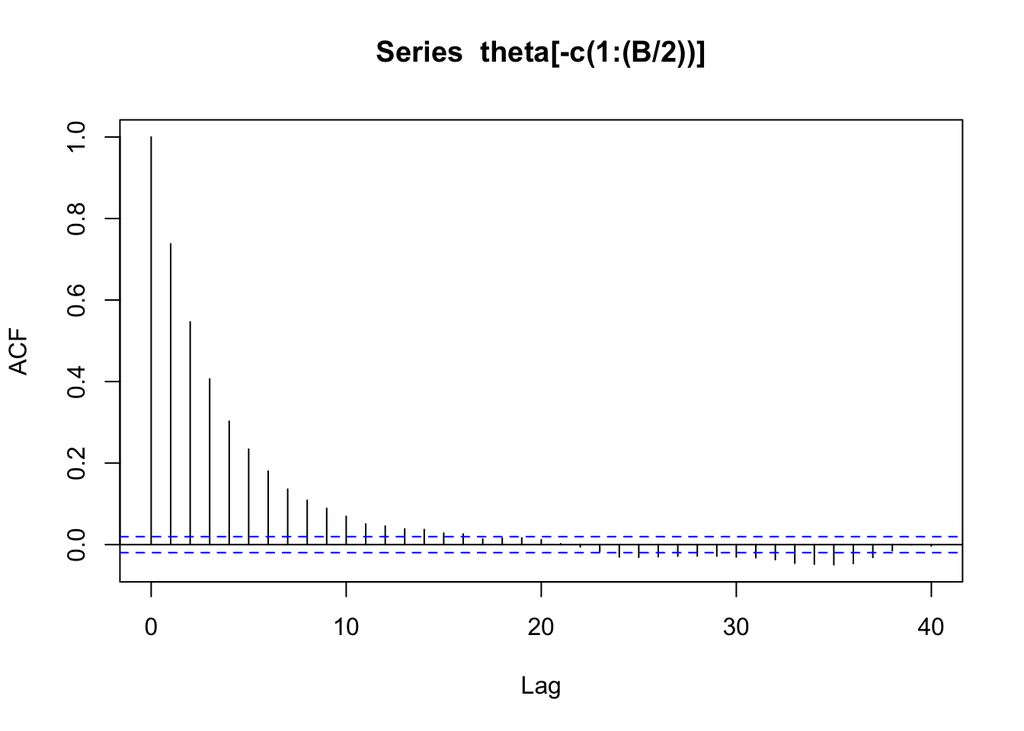

```r
acf(theta[-c(1:(B/2))])
```

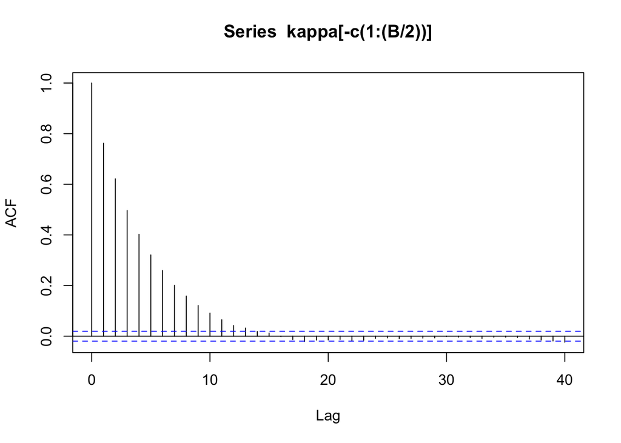

```r
acf(kappa[-c(1:(B/2))])
```

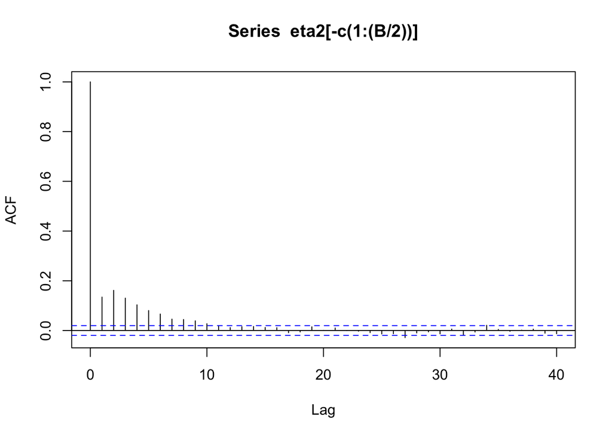

```r
acf(eta2[-c(1:(B/2))])
```

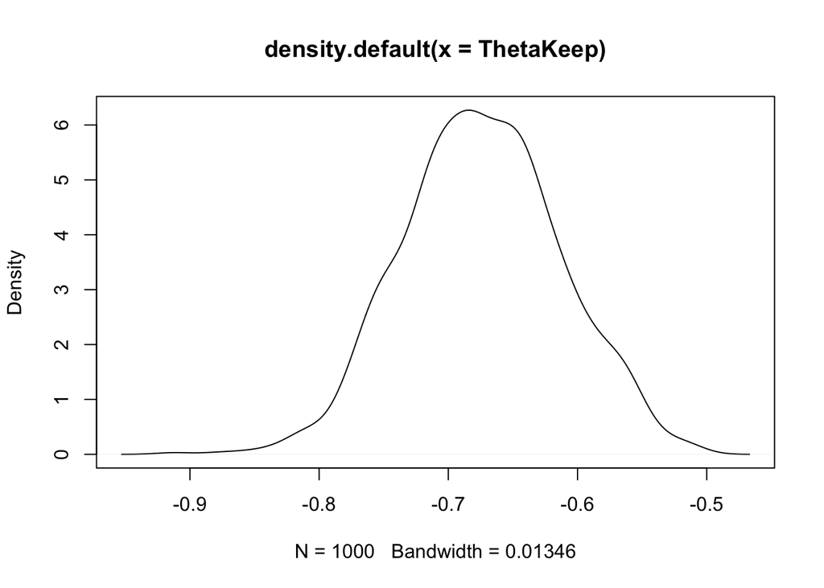

```r
keepIdx <- seq(burnIn+1, B, by = thin)
ThetaKeep <- theta[keepIdx]
KappaKeep <- kappa[keepIdx]
eta2Keep <- eta2[keepIdx]

plot(density(ThetaKeep))
```

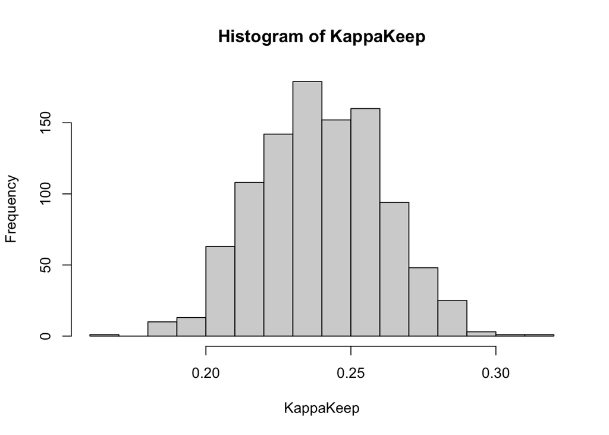

```r
hist(KappaKeep)
```

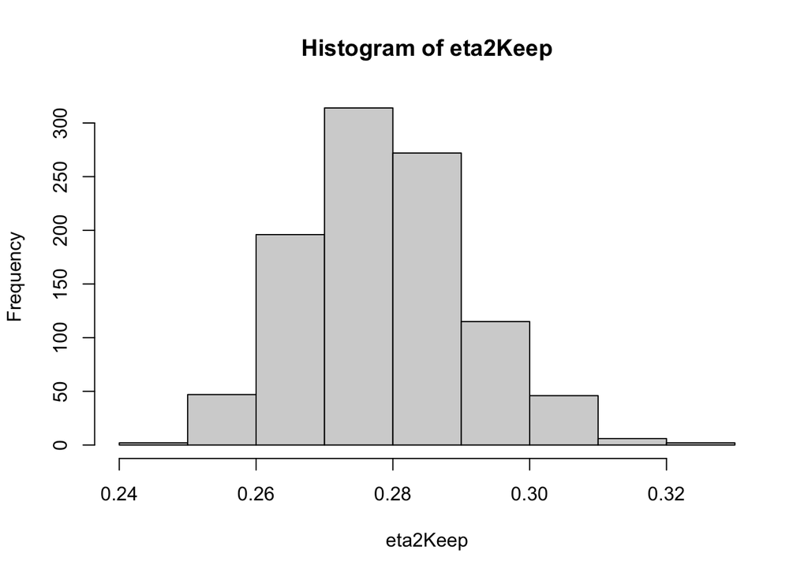

```r
hist(eta2Keep)
```

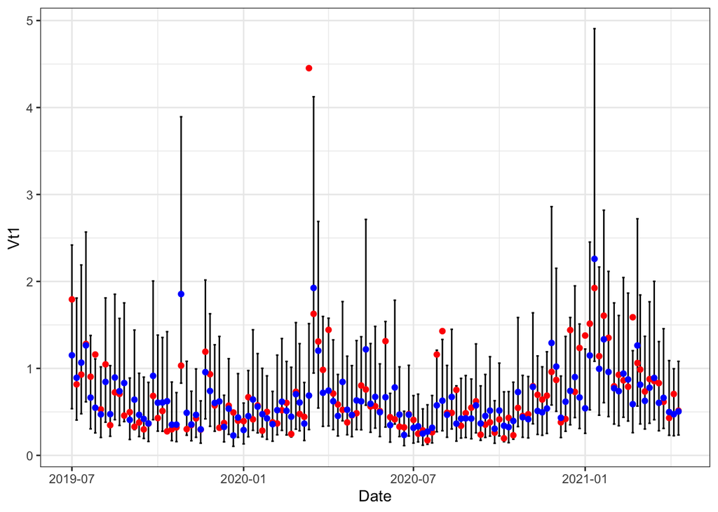

```r
calcXt1 <- function(Xt, k, eps2, theta, Date, n = 1000){
  mu <- Xt * exp(-k) + theta * (1 - exp(-k))
  var <- (eps2 * ( 1 - exp(-2*k))) / (2*k)
  Xt1 <- rnorm(n, mu, sqrt(var))
  simXt1 <- expand_grid(Date, Xt1) %>%
    mutate(Vt1 = exp(Xt1))
  return(simXt1)
}

K <- mean(KappaKeep)
Eps2  <- mean(eta2Keep)
Theta <- mean(ThetaKeep)

ParamsDf <- data.frame(k = K,
                       eps2 = Eps2,
                       theta = Theta) %>%
  expand_grid(test%>% select(Date, logAnnualRV)) %>%
  rename(Xt = logAnnualRV)

testSim <- pmap_dfr(ParamsDf, calcXt1)

testSim %>%
  rename(Xt1_pred = Xt1,
         Vt1_pred = Vt1) %>%
  group_by(Date) %>%
  mutate(upper = quantile(Vt1_pred, 0.95),
         lower = quantile(Vt1_pred, 0.05),
         pointEst = median(Vt1_pred)) %>%
  select(Date, upper, lower, pointEst) %>%
  distinct() %>%
  left_join(test %>% select(Date, AnnualizedRV, logAnnualRV)) %>%
  ungroup() %>%
  mutate(Xt1 = lead(logAnnualRV),
         Vt1 = lead(AnnualizedRV)) %>%
  filter(lubridate::day(Date) %in% c(1,6,11,16,21,26)) %>%
  # ggplot(aes(x = AnnualizedRV)) +
  # geom_point(aes(y = pointEst), col = "red") +
  #geom_point(aes(y = dVt), col = "blue")
  ggplot(aes(x = Date)) +
  geom_errorbar(aes(ymin = lower, ymax = upper)) +
  geom_point(aes(y = Vt1), col = "red")  +
  geom_point(aes(y = pointEst), col = "blue") +
  theme_bw()
```